# Advanced Bioinformatics_2019_assessment

9532

2019-06-06

```r
# CHECK R VERSION
# stopifnot(R.version.string == "R version 3.4.3 (2017-11-30)")

# CLEANUP
# Clear all variables:
rm(list=ls(all=TRUE))

# Unload current packages:
if (!is.null(names(utils::sessionInfo()[["otherPkgs"]]))) pacman::p_unload("all")
```

```r
# KNITR DEFAULTS
knitr::opts_chunk$set(eval = TRUE, fig.height = 10)
```

```r
# LOAD PACKAGES:
library(magrittr)
library(dplyr)
# library(ggplot2)
# library(calendar)
# library(stringr)
# library(rstudioapi)
```

# Task 1: Sum of all integers between 5 and 55.

```r
T1 <- sum(5:55)
print(T1)
```

[output not shown]

# Task 2: calculates the sum of all integers between 5 and n

```r
# Define a simple function

sumfun <- function(n){sum(5:n)}

# when n = 10, 20 and 100

sumfun(10)
sumfun(20)
sumfun(100)
```

[output not shown]

# Task 3: R script using a for loop to calculate and print out the first 12 entries of the Fibonacci series.

```r
my.a <- c(1,1)
for (i in 1:10) {
  my.a <- c(my.a,my.a[i] + my.a[i+1])
  print(my.a)
}
print(my.a)
```

[output not shown]

# Task 4: With the mtcars dataset bundled with R, use ggplot to generate a box of miles per gallon (in the variable mpg) as a function of the number of gears (in the variable gear). Tip: use the as.factor function to convert the gear variable from numeric into factor. For bonus point: use the fill aesthetic to colour bars by number of gears.

```r
# Load the ggplot package
library(ggplot2)
# Explore the mtcars data frame with str()
str(mtcars)
```

```
'data.frame':   32 obs. of  11 variables:
 $ mpg : num  21 21 22.8 21.4 18.7 18.1 14.3 24.4 22.8 19.2 ...
 $ cyl : num  6 6 4 6 8 6 8 4 4 6 ...
 $ disp: num  160 160 108 258 360 ...
 $ hp  : num  110 110 93 110 175 105 245 62 95 123 ...
 $ drat: num  3.9 3.9 3.85 3.08 3.15 2.76 3.21 3.69 3.92 3.92 ...
 $ wt  : num  2.62 2.88 2.32 3.21 3.44 ...
 $ qsec: num  16.5 17 18.6 19.4 17 ...
 $ vs  : num  0 0 1 1 0 1 0 1 1 1 ...
 $ am  : num  1 1 1 0 0 0 0 0 0 0 ...
 $ gear: num  4 4 4 3 3 3 3 4 4 4 ...
 $ carb: num  4 4 1 1 2 1 4 2 2 4 ...
```

```r
#as.factor(mtcars$gear)
```

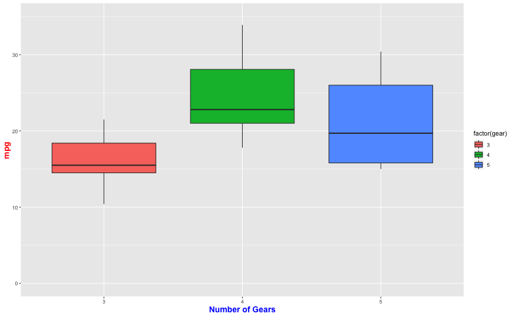

```r
# Boxplot mpg ~ gear

ggplot(mtcars, aes(x=factor(gear),y=mpg,fill=factor(gear)))+
  geom_boxplot(notch=F)+
  scale_x_discrete("Number of Gears")+
  scale_y_continuous("Miles per Gallon")+theme(
  axis.title.x = element_text(color = "blue", size = 14, face = "bold"),
  axis.title.y = element_text(color = "red", size = 14, face = "bold")
  )+
  scale_y_continuous(limits = c(0,35))
```

```r
  ggtitle("MPG by Number of Gears")
```

```
$title
[1] "MPG by Number of Gears"

attr(,"class")
[1] "labels"
```

# Task 5. Using the cars dataset and the function lm, fit a linear relationship between speed (in units of mph) and breaking distance (in units of feet) in the variable distance. What are the fitted slope and intercept of the line, and their standard deviations?

```r
head(cars)
dim(cars)
class(cars)
```

[output not shown]

Simple regression model is a straight line. The formula is Y=s0+(s1x1) Where s0 -> *y-intercept of the line, s1->* fitted slope, x1 -> *input variable speed(mph) and Y ->* output variable dist(feet).

```r
# The Linear Model Function

cor(cars$speed, cars$dist) #  0.8068949 indicate high positive correlation between speed and distance
```

```
[1] 0.8068949
```

```r
cars.lm <- lm(cars$dist ~ cars$speed)
print(cars.lm)
```

```
Call:
lm(formula = cars$dist ~ cars$speed)

Coefficients:
(Intercept)   cars$speed
    -17.579        3.932
```

```r
summary(cars.lm)
```

```
Call:
lm(formula = cars$dist ~ cars$speed)

Residuals:
    Min      1Q  Median      3Q     Max
-29.069  -9.525  -2.272   9.215  43.201

Coefficients:
            Estimate Std. Error t value Pr(>|t|)
(Intercept) -17.5791     6.7584  -2.601   0.0123 *
cars$speed    3.9324     0.4155   9.464 1.49e-12 ***
---
Signif. codes:  0 ‘***’ 0.001 ‘**’ 0.01 ‘*’ 0.05 ‘.’ 0.1 ‘ ’ 1

Residual standard error: 15.38 on 48 degrees of freedom
Multiple R-squared:  0.6511,    Adjusted R-squared:  0.6438
F-statistic: 89.57 on 1 and 48 DF,  p-value: 1.49e-12
```

```r
sd(cars$speed) #5.287644
```

```
[1] 5.287644
```

```r
sd(cars$dist) #25.76938
```

```
[1] 25.76938
```

```r
sd(resid(cars.lm))
```

```
[1] 15.22184
```

# Task 6. Use ggplot to plot the data points from Task 6 and the linear fit.

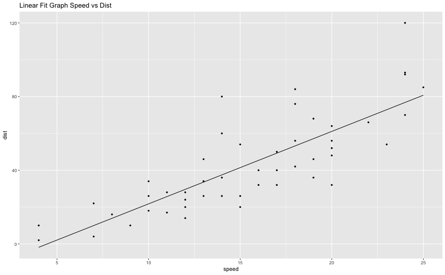

```r
cars %>%
  mutate( my_model = predict(cars.lm) ) %>%
  ggplot() +
  geom_point( shape=20, aes(speed, dist) ) +
  ggtitle("Linear Fit Graph Speed vs Dist") +
  scale_color_discrete(guide=FALSE) +
  geom_line( aes(speed, my_model) )
```

# Task 7. Again using the cars dataset, now use linear regression (lm) to estimate the average reaction time for the driver to start breaking (in seconds). To simplify matters you may assume that once breaking commences, breaking distance is proportional to the square of the speed. You may also use that 1 mile = 5280 feet and 1h = 3600 seconds. Note that you’ll need to use the I() function in the regression formula to make sure any non-linear terms gets treated literally, rather than as combinations of factors (e.g. I(x^2) for a term quadratic in the variable x). Do you get reasonable results? Finally, use ggplot to plot the data points and the fitted relationship.

```r
cars$new_speed <- cars$speed * (5280/3600)
y <- cars$dist
x <- cars$new_speed
x2 <- I(x^2)
cars_qm <- lm(y ~ 0 + x + x2)
summary(cars_qm)
```

```
Call:
lm(formula = y ~ 0 + x + x2)

Residuals:
    Min      1Q  Median      3Q     Max
-28.836  -9.071  -3.152   4.570  44.986

Coefficients:
   Estimate Std. Error t value Pr(>|t|)
x   0.84479    0.38180   2.213  0.03171 *
x2  0.04190    0.01366   3.067  0.00355 **
---
Signif. codes:  0 ‘***’ 0.001 ‘**’ 0.01 ‘*’ 0.05 ‘.’ 0.1 ‘ ’ 1

Residual standard error: 15.02 on 48 degrees of freedom
Multiple R-squared:  0.9133,    Adjusted R-squared:  0.9097
F-statistic: 252.8 on 2 and 48 DF,  p-value: < 2.2e-16
```

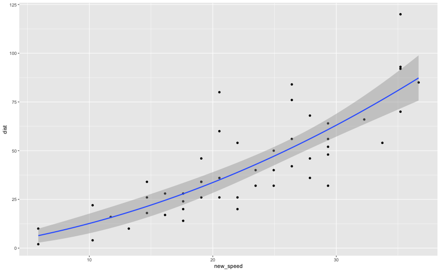

```r
library(ggplot2)
ggplot(cars,aes(new_speed,dist)) +
   geom_point() +
   geom_smooth(method="lm", formula="y~0+x+I(x^2)")
```

## Session info

```r
Sys.time()
```

[output not shown]

```r
# sessionInfo()
devtools::session_info()
```

[output not shown]